# Assignment5_BurialMoundHealth

## Task 2: Where in the landscape are the mounds located?

The location of settlements is usually easy to predict as humans need safety and easy access to water and food resources. These range from nearby arable soil to pasturage to trading centers. Choices regarding the mortuary realm are much harder to establish as they are guided by the social norms of the living rather than the natural environment. Some environmental conditions, however, play a role, such as intervisibility, which can be an important factor for societies that use monuments to the dead for territorial signalling. Before such specific analysis, it is, however, a good idea to get a general sense of where in the landscape are mounds located.

In order to produce a formal assessment of mound location, you can start by using most common aspects of topography, such as elevation, slope, aspect, and water proximity. Choose one or more of these variables. Calculate the distribution of classes of each environmental variable through the entire region (defining, en route, what you consider to be a “region”?) by extracting values from the digital elevation model and binning them in several classes. Then, calculate site frequencies within classes of the environmental variable by sampling mound locations in the raster and evaluate whether the observed pattern could be a product of the distribution of environmental categories themselves.

An example workflow with elevations could look like this: 1. Extract elevation values from the entire landscape and bin them in elevation categories (e.g. 400-500m, 500-600m, 600-700m, etc.). Consider: what defines a landscape for the purpose of this study? You may wish to crop the Aster to a smaller but representative study area but make sure you justify your selection 2. Extract elevation values from observed mound locations and review their distribution in the same bins 3. Calculate the expected number of mounds per bin if mounds were located through the landscape randomly 4. Compare the expected number with the observed one

**Packages**

```r
library(tidyverse)
library(raster)
library(sf)
library(lattice)
library(latticeExtra)
library(RColorBrewer)
library(rasterVis)
library(rgdal)
library(tmap)
```

**Data** For this task I will need the digital elevation for the Kazanlak Valley with 30m resolution, which is the “Aster.tif” file. I will also be needing the shapefile containing the GPS points for each mound in the Kazanlak valley which is stored in the “Kaz_mounds.shp” file.

```r
mounds <- st_read("data/KAZ_mounds.shp") # shapefile of mound coordinates
aster <- raster("data/Aster.tif") # raster data of elevation
```

**Examining Elevation** To get a general sense of where in the landscape the mounds are located, I will first examine the elevation for the region of interest, which is the region in which the mounds are located.

Before beginning to extract values from the raster, I need to make sure that the data share the same coordinate reference system (CRS), and if not I need to project to a common CRS.

```r
st_crs(mounds) # WGS84, UTM 35N zone
```

```
## Coordinate Reference System:
##   User input: 32635
##   wkt:
## PROJCS["WGS 84 / UTM zone 35N",
##     GEOGCS["WGS 84",
##         DATUM["WGS_1984",
##             SPHEROID["WGS 84",6378137,298.257223563,
##                 AUTHORITY["EPSG","7030"]],
##             AUTHORITY["EPSG","6326"]],
##         PRIMEM["Greenwich",0,
##             AUTHORITY["EPSG","8901"]],
##         UNIT["degree",0.0174532925199433,
##             AUTHORITY["EPSG","9122"]],
##         AUTHORITY["EPSG","4326"]],
##     PROJECTION["Transverse_Mercator"],
##     PARAMETER["latitude_of_origin",0],
##     PARAMETER["central_meridian",27],
##     PARAMETER["scale_factor",0.9996],
##     PARAMETER["false_easting",500000],
##     PARAMETER["false_northing",0],
##     UNIT["metre",1,
##         AUTHORITY["EPSG","9001"]],
##     AXIS["Easting",EAST],
##     AXIS["Northing",NORTH],
##     AUTHORITY["EPSG","32635"]]
```

```r
crs(aster) # WGS84, UTM 35N zone
```

```
## CRS arguments:
##  +proj=utm +zone=35 +datum=WGS84 +units=m +no_defs +ellps=WGS84
## +towgs84=0,0,0
```

Since they share a common CRS I will not need to reproject.

Checking the satellite imagery by plotting:

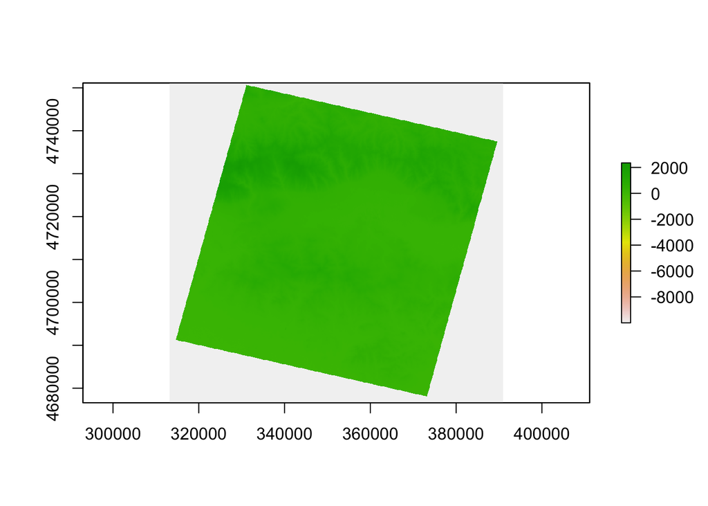

```r
plot(aster)
```

This does not look right. From the plot I can see that there is a need to reclassify values that are between -10.000 and -1 to NAs. Missing values are commonly coded as -9999 and this is why they are scewing the rendering of the raster data, and we need to fix this with reclassification.

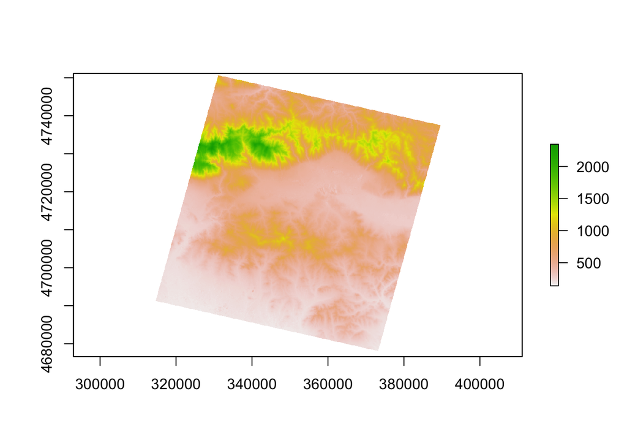

```r
rclmat <- cbind(-10000,-1, NA) # specifying what we want to reclassify
aster_reclass <- reclassify(aster, rcl = rclmat) # reclassifying the aster data
plot(aster_reclass) # plotting to make sure we fixed the issue
```

Now the satellite imagery looks much better and we can continue. Before extracting values from the landscape, we need to crop it to a smaller, but more representative region. It makes sense to crop the landscape to only contain the area in which the burial mounds are located, so that it what we will do. We can use the crop() function to crop the landscape to only include the region in which the mounds are located. The crop() function enables us to take the elevation data from the individual mounds only.

```r
cropped_aster <- crop(aster_reclass, mounds) # Extracting the elevation data for each mound
```

Let’s plot the cropped aster elevation data together with the coordinates of the burial mounds.

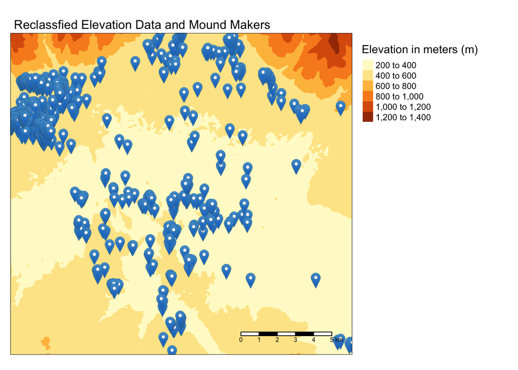

```r
# Plotting with tmap
tm_shape(cropped_aster) +
  tm_raster(title = "Elevation in meters (m)") +
  tm_shape(mounds) +
  tm_markers(size = 0.3) +
  tm_scale_bar() +
  tm_layout(main.title = "Reclassfied Elevation Data and Mound Makers",
            main.title.size = 1,
            legend.outside = T)
```

Now we can extract the elevation values from region in which the mounds are located.

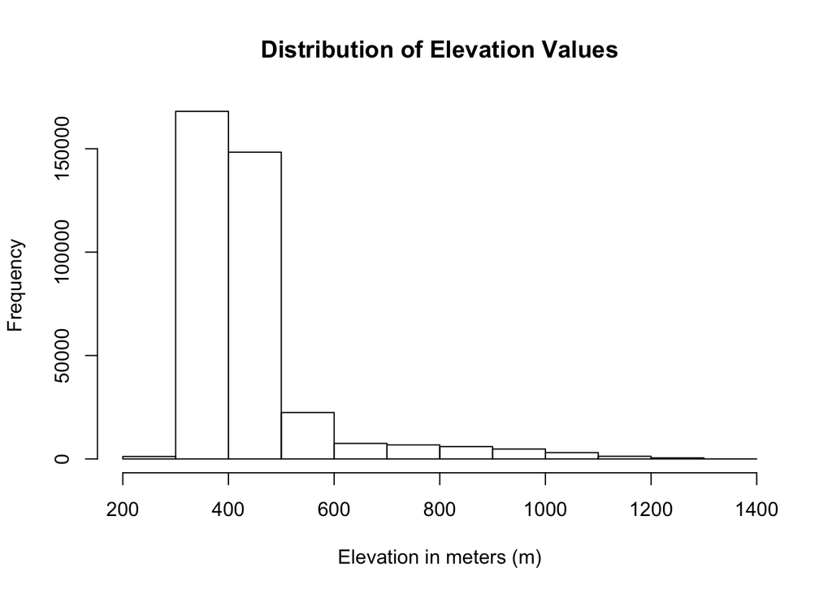

```r
# Defining elevation bins
elev_breaks <- c(200, 300, 400, 500, 600, 700, 800, 900, 1000, 1100, 1200, 1300, 1400)

# Extracting elevation values from landscape
aster_cropped_elev <- values(cropped_aster)

# Histogram
hist(aster_cropped_elev,
     breaks = elev_breaks,
     xlab = "Elevation in meters (m)",
     main = "Distribution of Elevation Values")
```

```r
# Putting the elevation data into bins and calculating the frequency
elevation_bins <- data.frame(table(cut(values(aster_reclass), breaks = elev_breaks, dig.lab = 5))) # dig.lab = 5 means 5 digits
elevation_bins
```

```
##           Var1   Freq
## 1    (200,300] 576862
## 2    (300,400] 677117
## 3    (400,500] 641782
## 4    (500,600] 445789
## 5    (600,700] 333719
## 6    (700,800] 282776
## 7    (800,900] 242529
## 8   (900,1000] 175228
## 9  (1000,1100] 134082
## 10 (1100,1200] 113689
## 11 (1200,1300]  90453
## 12 (1300,1400]  52328
```

Now we can move on to examining the distribution of elevation values for the mounds in only.

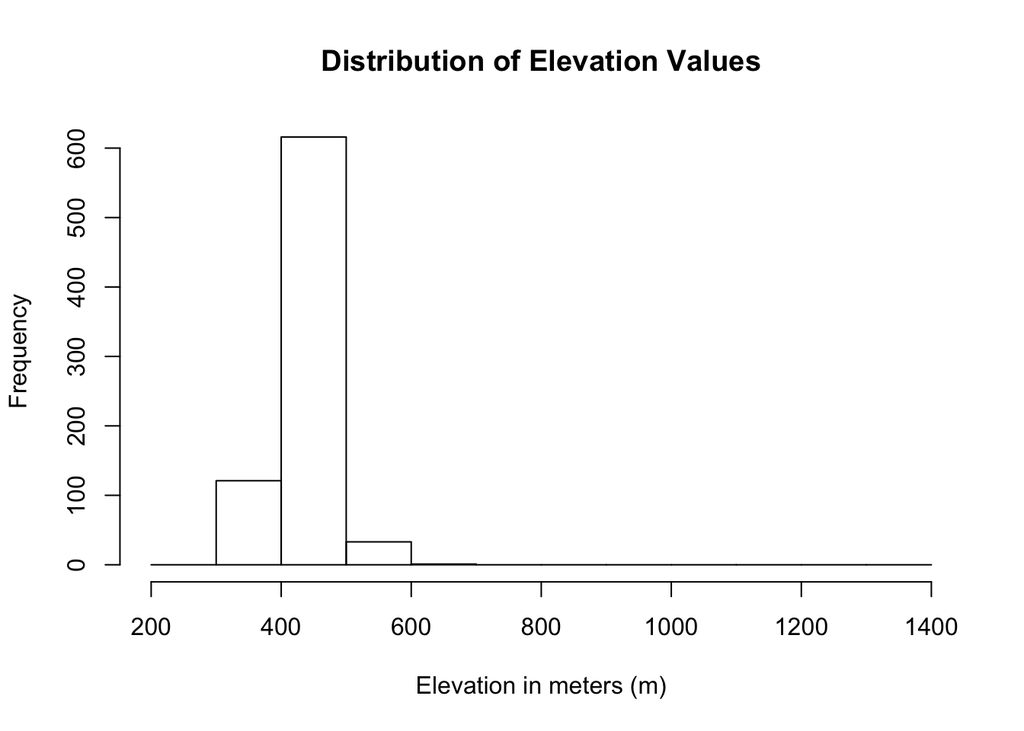

```r
# Extracting the elevation values for burial mounds
mounds$elevation <- raster::extract(cropped_aster, mounds)

# Examine the distribution of elevation values with a histogram
hist(mounds$elevation,
     breaks = elev_breaks,
     xlab = "Elevation in meters (m)",
     main = "Distribution of Elevation Values")
```

```r
# Calcualting the exact frequency of mounds per bin.
mounds_freq <- data.frame(table(cut(mounds$elevation, breaks = elev_breaks, dig.lab = 5)))
mounds_freq
```

```
##           Var1 Freq
## 1    (200,300]    0
## 2    (300,400]  121
## 3    (400,500]  616
## 4    (500,600]   33
## 5    (600,700]    1
## 6    (700,800]    0
## 7    (800,900]    0
## 8   (900,1000]    0
## 9  (1000,1100]    0
## 10 (1100,1200]    0
## 11 (1200,1300]    0
## 12 (1300,1400]    0
```

Now we have the observed freuqnecies per bin, and we know that most burials mounds (616) are located in areas with an elevation between 400 and 500. Now we can calcualte the number of mounds per bin that would be expected if mounds were RANDOMLY located through the landscape. We do so by taking a random sample of mounds from the cropped region and extract their elevation values and examine the distribution of these elevation values to compare with the expected elevation values we found above.

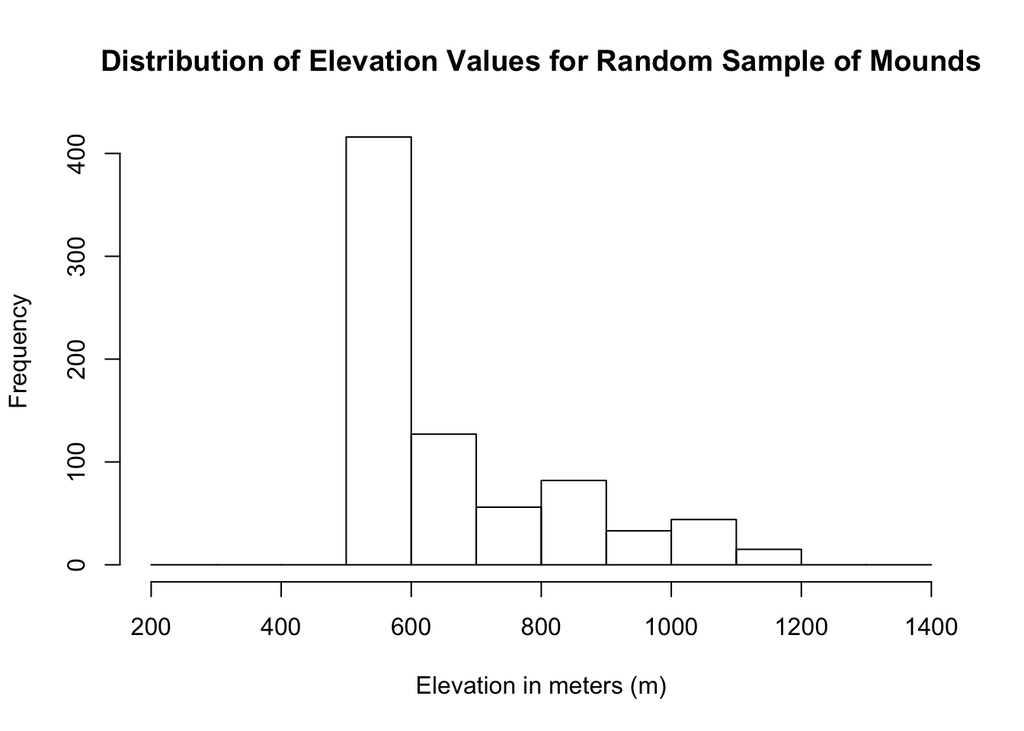

```r
set.seed(1) # set seed to get the same values each time we take a sample
random <- sampleRandom(cropped_aster, 773) # taking a random sample of mounds from the cropped area
random_elevation = raster::extract(cropped_aster, random) # extracting the elevation values from the random sample
hist(random_elevation,
     breaks = elev_breaks,
     xlab = "Elevation in meters (m)",
     main = "Distribution of Elevation Values for Random Sample of Mounds") # examining the elevation value distribution for the random sample
```

```r
random_freq <- data.frame(table(cut(random_elevation, breaks = elev_breaks, dig.lab = 5))) # calcuating the expected frequency per bin
random_freq
```

```
##           Var1 Freq
## 1    (200,300]    0
## 2    (300,400]    0
## 3    (400,500]    0
## 4    (500,600]  416
## 5    (600,700]  127
## 6    (700,800]   56
## 7    (800,900]   82
## 8   (900,1000]   33
## 9  (1000,1100]   44
## 10 (1100,1200]   15
## 11 (1200,1300]    0
## 12 (1300,1400]    0
```

Let’s take a look at the distributions next to each other to compare.

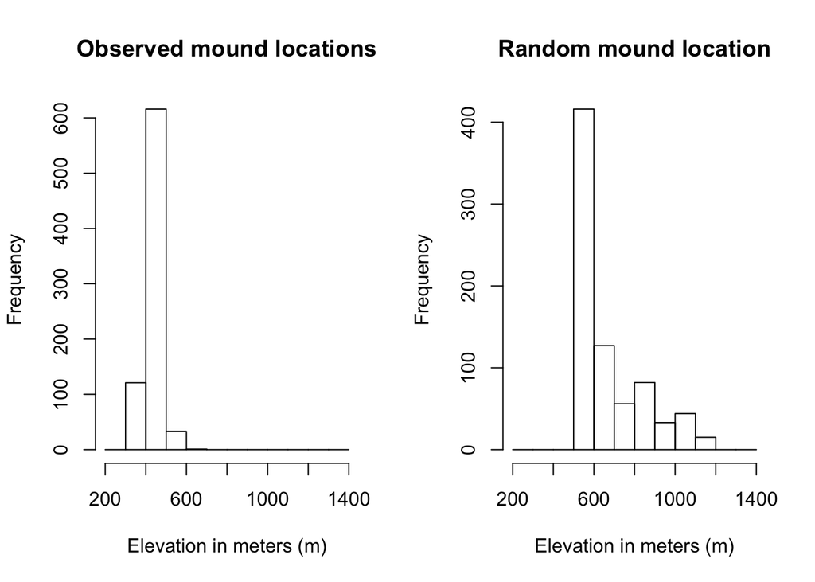

```r
par(mfrow=c(1,2)) # 1 row with 2 columns

# Observed mound locations
hist(mounds$elevation,
     breaks = elev_breaks,
     xlab = "Elevation in meters (m)",
     main = "Observed mound locations")

# Random mound locations
hist(random_elevation,
     breaks = elev_breaks,
     xlab = "Elevation in meters (m)",
     main = "Random mound location")
```

Now we have looked at elevation to assess the location of burial mounds, and now we turn to look at the slope for the burial mounds and see if this can tell us more about why the burials mounds are located where they are.

**Examining Slope** Below we are going to look at the slopes of the burial mounds to see if the slopes of the burials mounds seem random or if there is a particular pattern present. Hence, we basically repeat what we did above with the elevation data.

First we need to extract the slope values for the burial mounds

```r
slopes <- terrain(cropped_aster, opt = "slope", unit = "degrees") # extracting slope values
```

Now we can define the bins for the slope values and examine the distribution of mounds according to slope.

```r
# Define bins
slope_breaks <- c(0, 5, 10, 15, 20, 25, 30, 35, 40, 45, 50, 55, 60)

# Extract slope values from the mounds
mounds$slope <- raster::extract(slopes, mounds)

# Put the slope values into bins
slopes_bins_freq <- data.frame(table(cut(mounds$slope, breaks = slope_breaks, dig.lab = 5)))
slopes_bins_freq
```

```
##       Var1 Freq
## 1    (0,5]  595
## 2   (5,10]  133
## 3  (10,15]   28
## 4  (15,20]    4
## 5  (20,25]    2
## 6  (25,30]    0
## 7  (30,35]    1
## 8  (35,40]    0
## 9  (40,45]    0
## 10 (45,50]    0
## 11 (50,55]    0
## 12 (55,60]    0
```

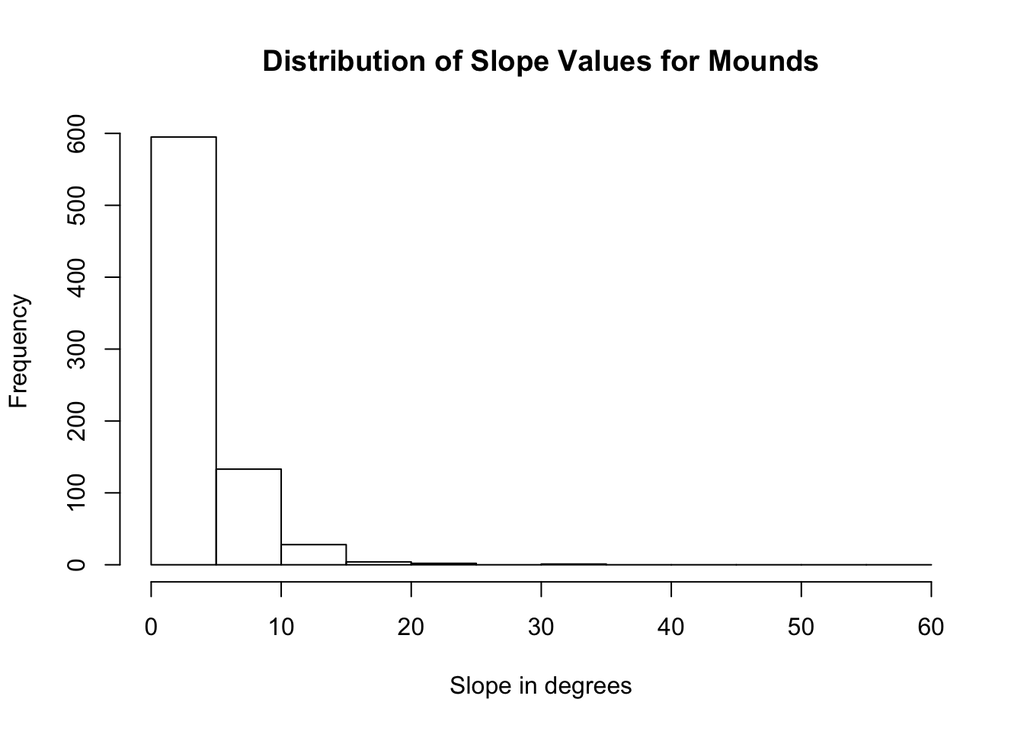

```r
# Examine distribution with a histogram
hist(mounds$slope,
     breaks = slope_breaks,
     xlab = "Slope in degrees",
     main = "Distribution of Slope Values for Mounds")
```

From the above, we can see that most burials mounds (595) are located in areas with a slope between 0 and 5 degrees.

Now we can calculate the expected number of mounds per bin if the mounds were located randomly through the landscape, and see how this compares to what we actually observe.

```r
set.seed(1) # set seed to get the same values each time we take a sample
random_slopes <- sampleRandom(slopes, 773) # taking a random sample of mounds from the cropped area
random_freq <- data.frame(table(cut(random_slopes, breaks = slope_breaks, dig.lab = 5))) # calcuating the expected frequency per bin
random_freq
```

```
##       Var1 Freq
## 1    (0,5]  475
## 2   (5,10]  181
## 3  (10,15]   47
## 4  (15,20]   24
## 5  (20,25]   18
## 6  (25,30]   16
## 7  (30,35]    5
## 8  (35,40]    3
## 9  (40,45]    3
## 10 (45,50]    0
## 11 (50,55]    0
## 12 (55,60]    0
```

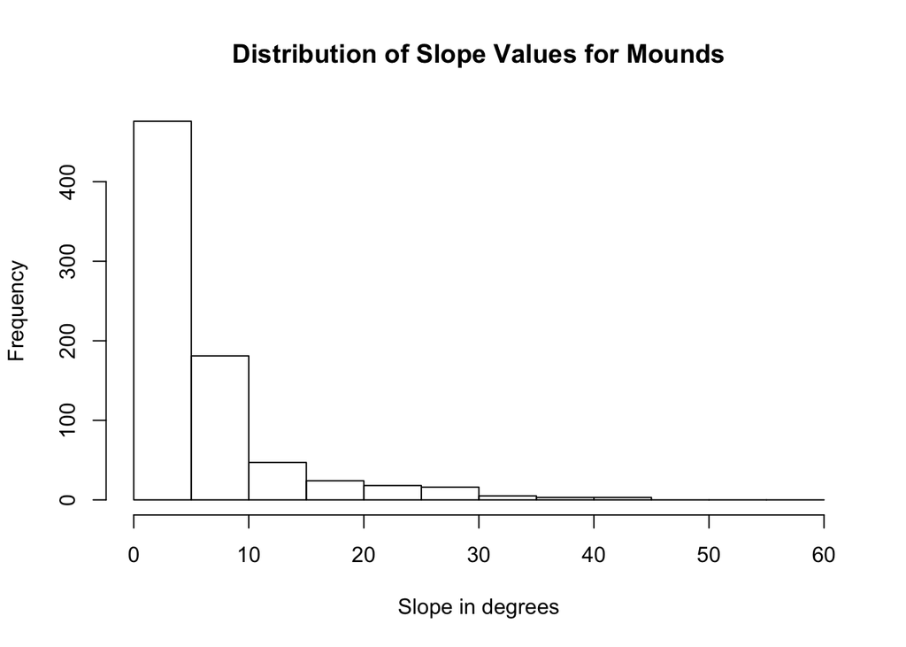

```r
# examining the elevation value distribution for the random sample
hist(random_slopes,
     breaks = slope_breaks,
     xlab = "Slope in degrees",
     main = "Distribution of Slope Values for Mounds")
```

Let’s take a look at the distributions next to each other to compare

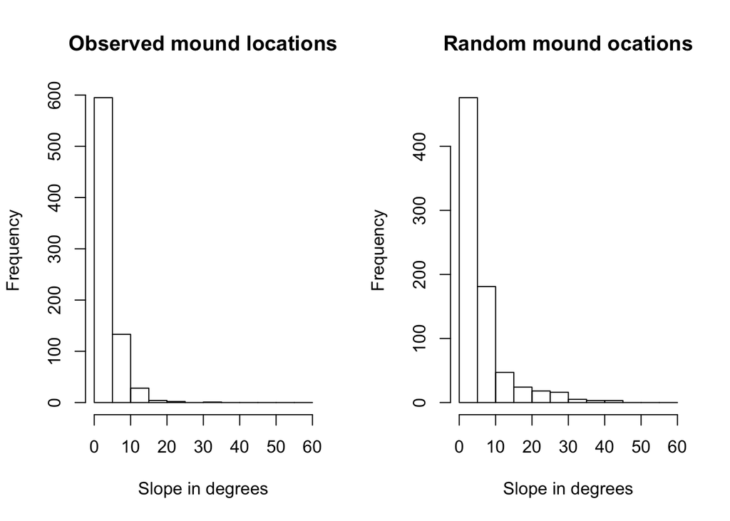

```r
par(mfrow=c(1,2)) # 1 row with 2 columns

# Observed mound locations
hist(mounds$slope,
     breaks = slope_breaks,
     xlab = "Slope in degrees",
     main = "Observed mound locations")

# Random mound locations
hist(random_slopes,
     breaks = slope_breaks,
     xlab = "Slope in degrees",
     main = "Random mound ocations")
```